# Analisis evolutivo y correlativo del consumo de alcohol, tabaco y estado de salud

Victor Brown Sogorb, Nicolas Garcia Gomez, Sara Meda Lopez

2024-12-01

## Introducción

ESTE ARCHIVO Y TODO EL TRABAJO SE ENCUENTRA EN EL GITHUB([AQUI](https://github.com/vicBrownS/Seminario_Fuentes_Victor_Nicolas_Sara.git))

Como se indica en el archivo README el objetivo de este trabajo es el análisis de la evolución y correlación entre ciertos determinantes de salud y el estado general de salud de la población española.

Los datos utilizados provienen de la encuesta europea de salud que el INE ha realizado en los años 2009, 2014 y 2020. Para acceder a los datos se utiliza el portal web del INE ([AQUI](https://www.ine.es/dyngs/INEbase/operacion.htm?c=Estadistica_C&cid=1254736176784&menu=resultados&idp=1254735573175)).

Referencias:

-Rehm J, Rovira P, Llamosas-Falcón L, Shield KD. Dose-Response Relationships between Levels of Alcohol Use and Risks of Mortality or Disease, for All People, by Age, Sex, and Specific Risk Factors. Nutrients. 2021 Jul 30;13(8):2652. doi: 10.3390/nu13082652. PMID: 34444809; PMCID: PMC8401096.

-Im PK, Wright N, Yang L, Chan KH, Chen Y, Guo Y, Du H, Yang X, Avery D, Wang S, Yu C, Lv J, Clarke R, Chen J, Collins R, Walters RG, Peto R, Li L, Chen Z, Millwood IY; China Kadoorie Biobank Collaborative Group. Alcohol consumption and risks of more than 200 diseases in Chinese men. Nat Med. 2023 Jun;29(6):1476-1486. doi: 10.1038/s41591-023-02383-8. Epub 2023 Jun 8. PMID: 37291211; PMCID: PMC10287564.

-Sha M, Sun JQ, Xia Q. The alcohol flushing syndrome: A risk factor for cancer. Ann Acad Med Singap. 2024 Jul 30;53(7):405-406. doi: 10.47102/annals-acadmedsg.2024191. PMID: 39132956.

-Thibaut F. Alert out on tobacco and alcohol consumption in young European women. Eur Arch Psychiatry Clin Neurosci. 2018 Jun;268(4):317-319. doi: 10.1007/s00406-018-0901-7. PMID: 29737407.

## Criterios y consideraciones sobre los datos

Los criterios utilizados para fitrar la enorme cantidad de datos proveniente de esta encuesta son los siguientes:

- Los datos a tratar han de tener su resultado en cifras relativas, es decir, tienen que estar expresados en porcentajes.
- Los datos a tratar han de estar agrupados en función del sexo y de la comunidad autónoma.
- Los datos a tratar tienen que posibilitar un seguimiento de su evolución, es decir, tiene que aparecer una encuesta con las mismas categorías a través de los tres años que se estudian (2009, 2014, 2020).

Estos criterios permiten una unicidad en los datos que facilita su tratamiento y correlación.

Importante denotar las siguientes apreciaciones sobre los datasets utilizados:

- Todos los datos trabajan sobre una muestra poblacional de 35.000 personas de distintas comunidades autónomas.
- Todos los datasets están organizados en función de variables categóricas **(e.j sí ha fumado, no ha fumado)**, resaltar la inherente incapacidad de estos datos de representar con exactitud los sentimientos o situación del encuestado resultando en un riesgo de error y de sesgo creados por la forma de presentar el estudio.
- Todos los datos están sujetos a errores de muestreo y poseen sus coeficientes de variación correspondientes, por simplificar y facilitar la realización de este trabajo no se toman en cuenta estos coeficientes para el análisis estadístico. Se recomienda discreción en la consideración de la veracidad de los datos y resultados.

## Datos utilizados

Todos los datasets utilizados en este análisis son los siguientes:

1. [Consumo de bebidas alcohólicas en los últimos 12 meses según sexo y comunidad autónoma. Población de 15 y más años. (2009)](https://www.ine.es/jaxi/Tabla.htm?path=/t15/p420/a2014/p06/l0/&file=03004.px&L=0)
2. [Consumo de bebidas alcohólicas en los últimos 12 meses según sexo y comunidad autónoma. Población de 15 y más años.](https://www.ine.es/jaxi/Tabla.htm?path=/t15/p420/a2014/p06/l0/&file=03004.px&L=0) (2014)
3. Consumo de bebidas alcohólicas en los últimos 12 meses según sexo y comunidad autónoma. Población de 15 y más años. (2020)
4. [Consumo de tabaco según sexo y comunidad autónoma. Población de 16 y más años (2009)](https://www.ine.es/jaxi/Tabla.htm?path=/t15/p420/a2009/p06/l0/&file=04003.px&L=0)
5. [Consumo de tabaco según sexo y comunidad autónoma. Población de 15 y más años. (2014)](https://www.ine.es/jaxi/Tabla.htm?path=/t15/p420/a2014/p06/l0/&file=02004.px&L=0)
6. [Consumo de tabaco según sexo y comunidad autónoma. Población de 15 y más años. (2020)](https://www.ine.es/jaxi/Tabla.htm?path=/t15/p420/a2019/p06/l0/&file=02004.px&L=0)
7. [Valoración del estado de salud percibido en los últimos 12 meses según sexo y comunidad autónoma. Población de 16 y más años (2009)](https://www.ine.es/jaxi/Tabla.htm?path=/t15/p420/a2009/p04/l0/&file=01011.px&L=0)
8. [Valoración del estado de salud percibido en los últimos 12 meses según sexo y comunidad autónoma. Población de 16 y más años (2014)](https://www.ine.es/jaxi/Tabla.htm?path=/t15/p420/a2014/p04/l0/&file=01004.px&L=0)
9. [Valoración del estado de salud percibido en los últimos 12 meses según sexo y comunidad autónoma. Población de 16 y más años (2020)](https://www.ine.es/jaxi/Tabla.htm?path=/t15/p420/a2019/p04/l0/&file=01004.px&L=0)

## Metodología general-Visor de datos

Para toda la obtención de los resultados de este seminario se utiliza la herramienta desarrollada en este mismo seminario, el visor de datos.

Toda la información sobre el funcionamiento y objetivo del visor se puede ver en su documentación (**VisordeDatosDocu.html)**

La aplicación está disponible en este mismo GitHub y se deja la libertad al lector de trabajar con los datos y comprobar manualmente los resultados que se van a mostrar.

## Análisis evolutivo

Primeramente se realizara un análisis de la evolución de los datos tanto de los determinantes de salud, como de aquellos sobre el estado de salud. El objetivo de este análisis evolutivo es crear una base de información relevante para el análisis comparativo que se realizará posteriormente.

### Metodología del análisis evolutivo

Para realizar con rigurosidad y uniformidad un análisis de la evolución de los distintos datos se seguirá una misma metodología para cada uno de ellos. Para ello, se utilizará las funcionalidades que el visor de datos provee y se realizarán varios análisis de la evolución utilzando boxplots, histogramas y gráficos de densisdad. En cada dataset se utilizarán diferentes recursos y se hará una interpretación de cada resultado, indicando también los valores estadísticos exactos.

### Dataset: Alcohol

Los distintos datasets escogidos referentes al alcohol en los años 2009, 2014 y 2020 hacen el estudio sobre el consumo de bebidas alcohólicas en los últimos 12 meses, siendo las posibles respuestas: **sí ha consumido** y **no ha consumido**.

En la carpeta de `input\data` estos datasets son **Alcohol_2009.csv , Alcohol_2014.csv y Alcohol_2020. csv**. Estos se corresponden a los número 1, 2 y 3 de Datos utilizados.

#### Analisis en función del sexo

Primeramente se analizará la distribución del total en cada variable categórica en función del sexo, esto se observará en un diagrama de caja y se observara la evolución de estas variables en los tres años de la toma de datos.

**2009:**

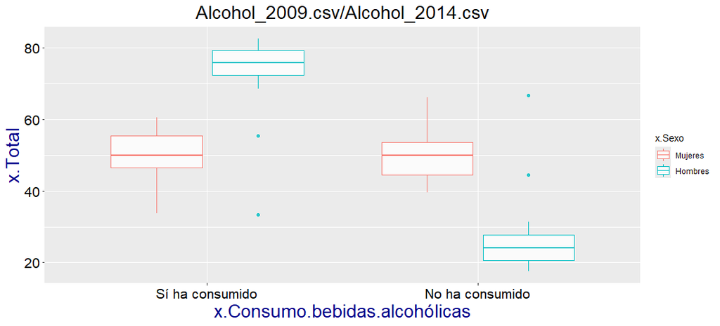

Hombres/sí ha consumido:

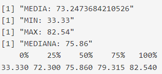

Mujeres/si ha consumido:

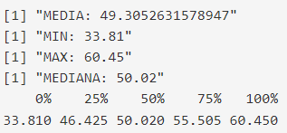

**2014:**

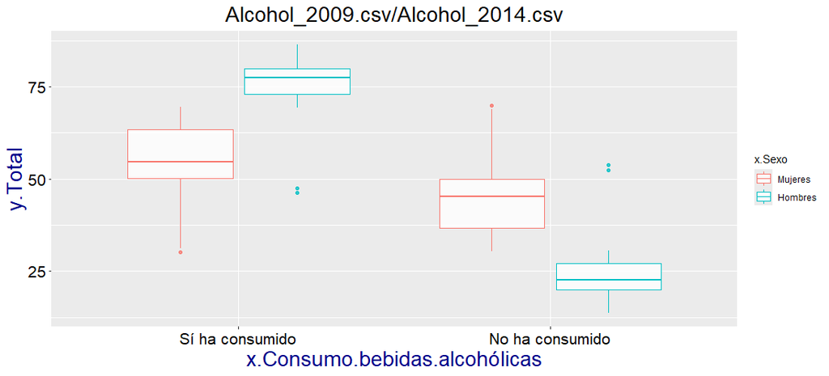

Hombres/sí ha consumido:

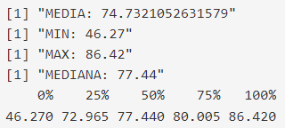

Mujeres/si ha consumido:

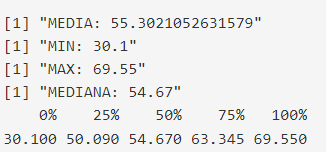

**2020:**

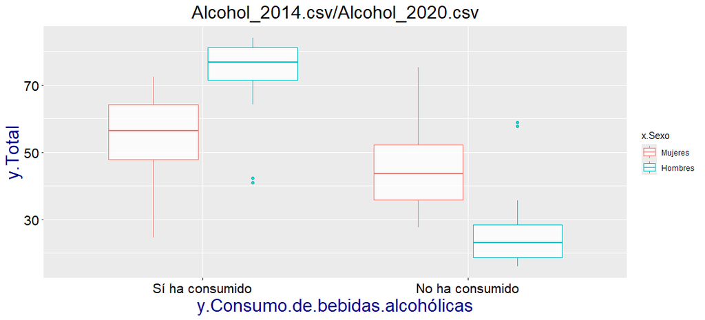

Hombres/sí ha consumido:

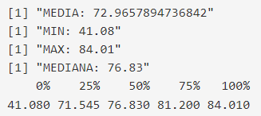

Mujeres/si ha consumido:

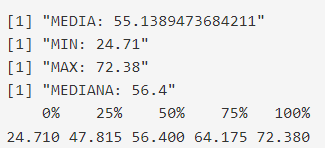

#### Analisis en función de las com. autonomas

También se analizará la evolución del consumo de alcohol y su variación en las distintas comunidades autónomas, nótese que los datos corresponden a los de la categoría “Ambos sexos” y atendiendo a la representación que se va a mostrar una caja más ancha representa un mayor consumo, debido a una diferencia mayor entre el dato “si ha consumido” y “no ha consumido”.

Luego de mostrar los gráficos de los 3 años se procederá a su explicación e interpretación.

**2009:**

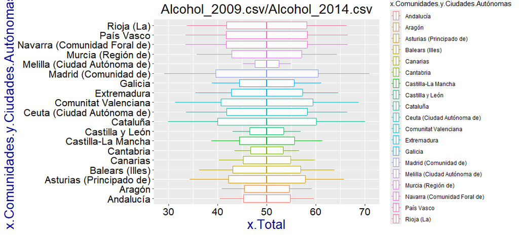

**2014:**

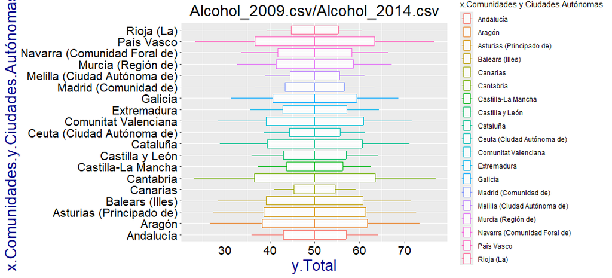

**2020:**

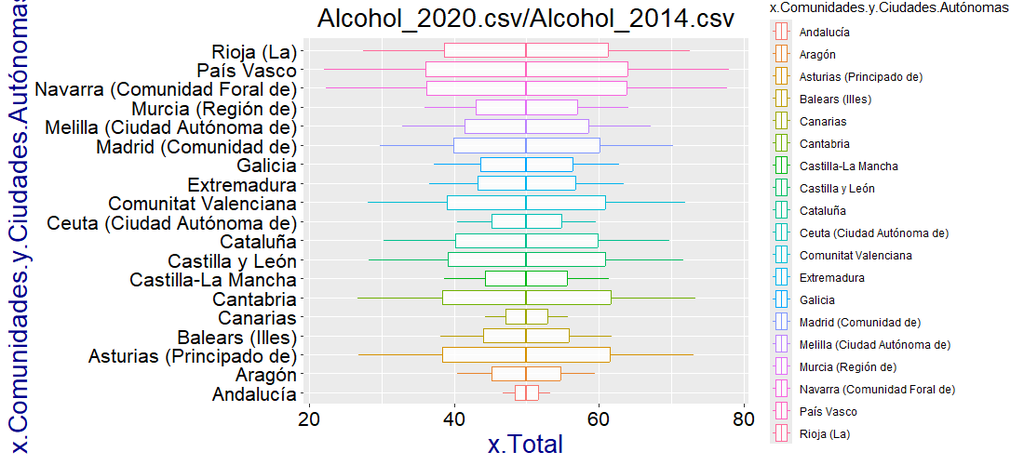

La interpretación de estos diagramas de cajas es ligeramente distinto respecto a los mostrados en el anterior análisis, en este caso, al solo existir solo dos datos, “si ha consumido” y “no ha consumido”, por comunidad autónoma la dispersión de la caja representa la diferencia entre estos valores, es decir, a mayor dispersión mayor consumo de alcohol. El valor real del consumo se encontraría en el extremo de cada boxplot, al final de la linea de color.

Observando las gráficas y los datos se puede ver como, pese a que el consumo de alcohol a aumentado de manera general entre 2009 a 2020, en específico de un 61% de media en las respuestas de “si ha consumido” en 2009 a un 64 % en 2020, hay mucha variación en la evolución de este mismo dato en diferentes comunidades autónomas, por ejemplo en Cantabria se ve un gran aumento del consumo frente a una gran reducción del mismo en Andalucía entre 2009 y 2020. Destacar también el caso de Canarias que mantiene un consumo por debajo de la media los 3 años de toma de datos e incluso se reduce desde 2009 hasta 2020.

### Dataset: Consumo de tabaco

Los distintos datasets escogidos referentes al consumo de tabaco en los años 2009, 2014 y 2020 hacen el estudio sobre los hábitos respecto al consumo, creando 4 categorias distintas: **Fumador diario, fumador ocasional, ex-fumador y nunca ha fumado**

En la carpeta de `input\data` estos datasets son **consumo_tabaco_2009.csv ,consumo_tabaco_204.csv y consumo_tabaco_2020.csv**. Estos se corresponden a los número 4, 5 y 6 de Datos utilizados.

#### Analisis en función del sexo

Primeramente se analizará la distribución del total en cada variable categórica en función del sexo, esto se observará en un diagrama de caja y se observara la evolución de estas variables en los tres años de la toma de datos

Debido al gran número de categorías en cada uno de los datasets no se mostraran imágenes con los datos de todas ellas, si no las que tengan información importante para el análisis, para ver más datos revisarlos manualmente en el visor de datos.

**2009:**

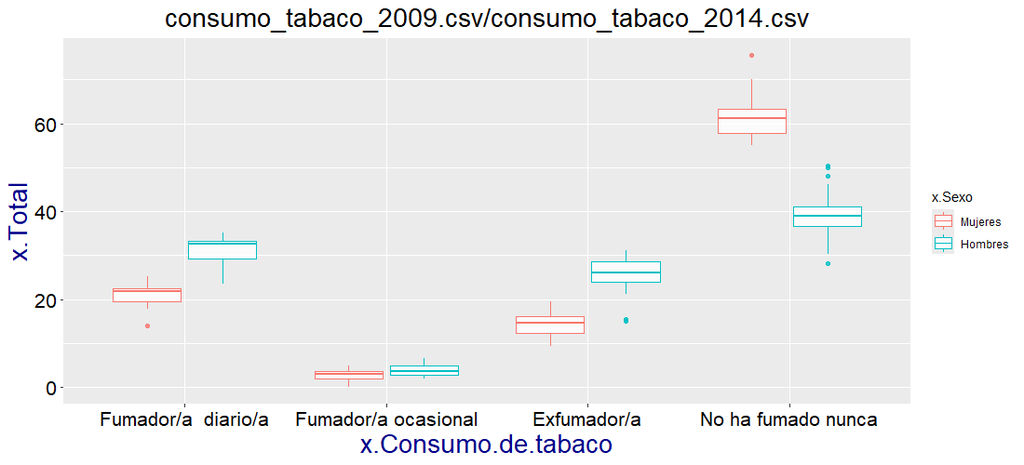

En 2009 se observa como aunque el número de personas que admite no haber fumado nunca es mayor a aquellos que son fumadores diario todavía estos comportan un gran porcentaje del total, mucho mayor en caso de hombres, concrétamente un 31% de media en comparación con un 21% en caso de las mujeres que fuman todos los días. Es fácil notar como hay un mayor porcentaje de hombres que consumen tabaco y que son ex-fumadores respecto a las mujeres, que tienen un mayor porcentaje en la categoría **no ha fumado nunca**. La dispersión de los valores es pequeña, reflejando unicidad de los valores entre comunidades autónomas. Los valores estadísticos apoyan estas observaciones:

Hombres/fumador diario:

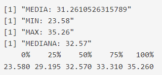

Mujeres/fumador diario:

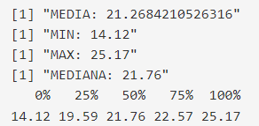

Hombres/no ha fumado nunca:

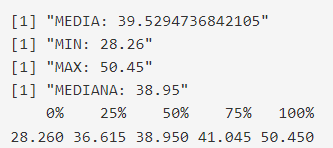

Mujeres/no ha fumado nunca:

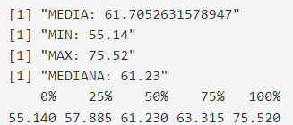

**2014:**

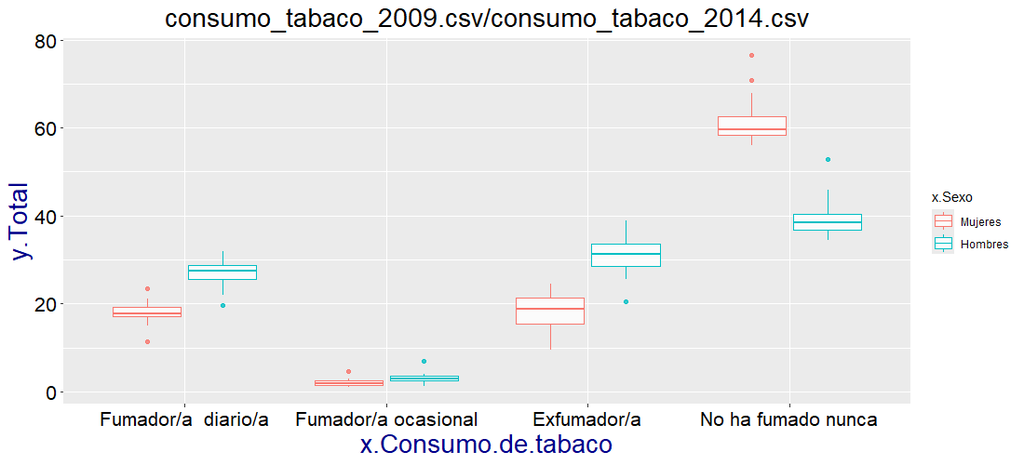

En 2014 se puede ver una reducción significativa en la cantidad de fumadores diarios en ambos sexos, sobre todo en el caso de los hombres, pasando de un 31 % de media en 2009 a un 26 % en 2014, en caso de las mujeres la reducción es menor de 21% a 17%. Este descenso en fumadores diarios se refleja en un aumento en el número de ex-fumadores, de un 25% de media en 2009 a un 31 en 2014 en hombres y de un 14 % a un 18 % en mujeres. Notese que el descenso en fumadores diarios ha afectado al número de ex-fumadores, como es lógico, mientras que la categoría de **no ha fumado nunca** mantiene unos valores parecidos, veremos como esto cambia en el próximo año. Los valores estadísticos apoyan estas observaciones:

Hombres/fumador diario:

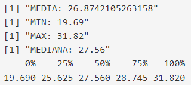

Mujeres/fumador diario:

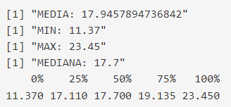

Mujeres/ex-fumador:

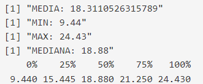

Hombres/ex-fumador:

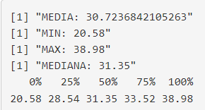

**2020:**

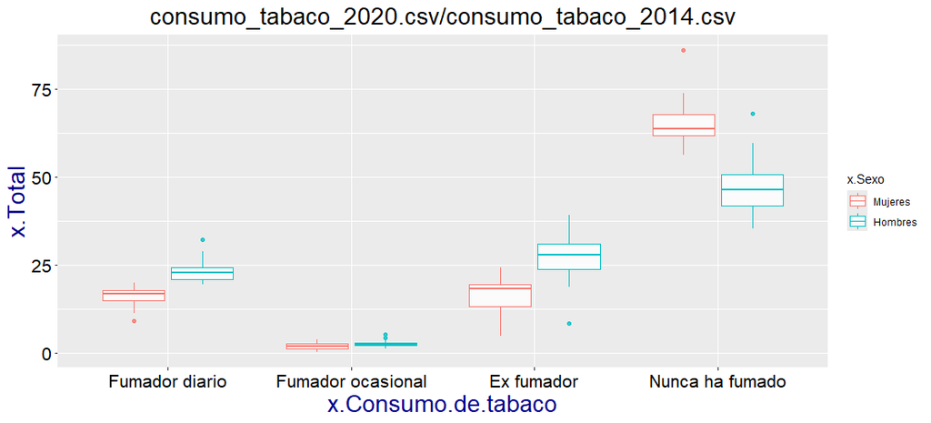

En 2020 se puede ver un cambio significativo en la distribución de las variables reflejado en el aumento de personas que admiten no haber fumado nunca y la reducción en fumadores diarios y ex-fumadores. Concrétamente en el caso de los hombres la categoría **no ha fumado nunca** aumenta de un 39 % en años anteriores a un 47 % en 2020. En mujeres aumenta de un 61% a un 65%. En materia de fumadores diarios también se aprecia una reducción de 3 puntos para hombres y 1 punto para mujeres.

Como tendencia general se puede concluir que el consumo de tabaco desciende significativamente desde el año 2009, lo que presuntamente debería aumentar el estado general de salud en todo el país.

Los datos estadísticos son los siguientes

Hombres/fumador diario:

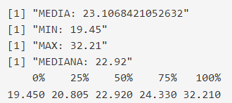

Mujeres/fumador diario:

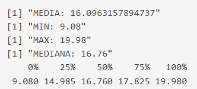

Hombres/nunca ha fumado:

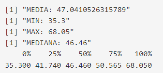

Mujeres/nunca ha fumado:

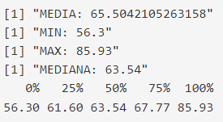

#### Analisis en función de las com. autonomas

También se analizará la evolución del consumo de tabaco en las distintas comunidades autónomas, para ello se visualizará un histograma con los datos de cada categoría (**Fumador diario, fumador ocasional, ex-fumador, nunca ha fumado**) en los distintos años de toma de datos, en estos histogramas se podrá ver a través del mapping las comunidades autónomas.

Los datos son filtrados en función de la variable “Ambos Sexos”, por lo que solo existe una instancia de cada dato para cada comunidad autónoma.

**Fumador diario:**

**2009:**

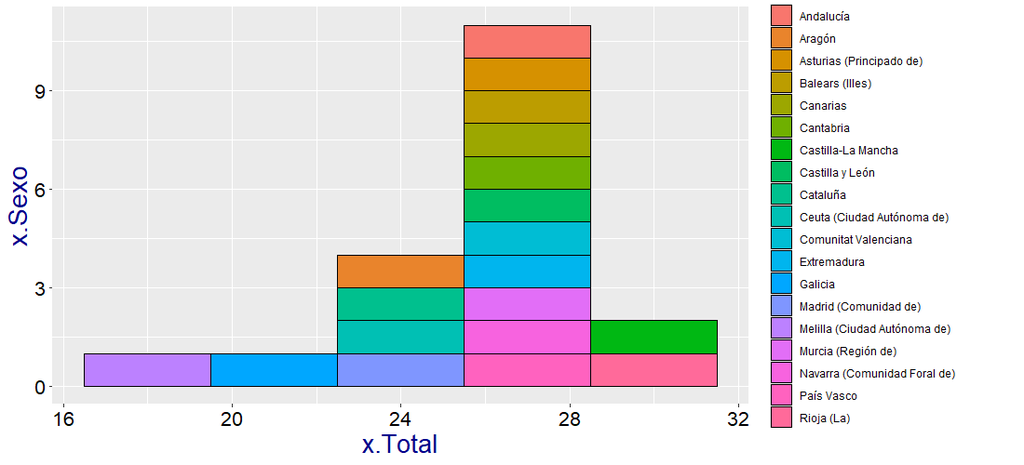

**2014:**

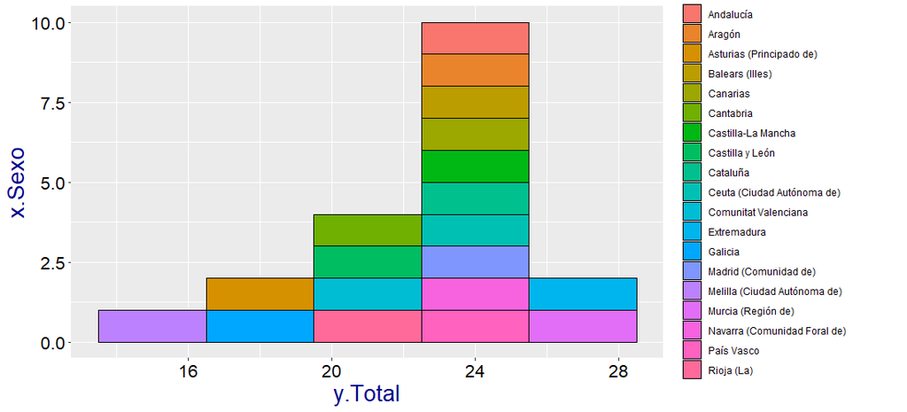

**2020:**

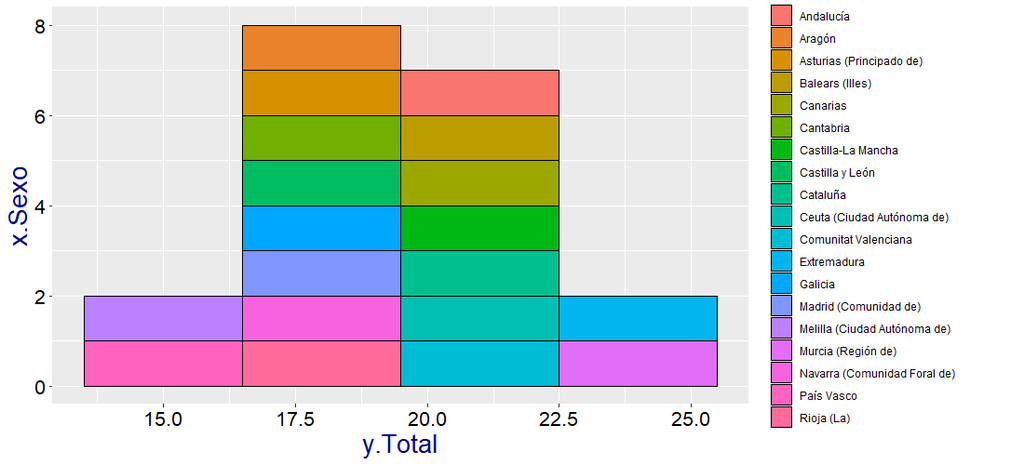

En la categoría de **fumador diario** se observa como la reducción de la proporción de estas respuestas disminuye en todas las comunidades autónomas, sin embargo, se puede observar como en la ciudad autónoma de Melilla no se reduce tanto debido a que este dato ya estaba en torno al 15%-18% en 2009. Notese como la distribución se va normalizando con el paso del tiempo, siendo los datos más alejados de la media los de Melilla, Navarra (por debajo), Galicia y Murcia (por encima).